[figure not shown]

# Churn Analysis

Exploratory Data Analysis & Retention Insights

### 📌 Project Overview

**▶ Click to expand project overview**

TL;DR: Retention is strong (≈83%), but churn correlates most strongly with recent engagement, usage frequency, and driving behavior patterns. These insights help inform targeted retention strategy and future churn-prediction modeling.

This project explores driver engagement and churn behavior using Waze usage data. The goal is to identify trends that distinguish retained users from churned users and uncover behavioral signals that may predict churn risk. Insights from this exploratory work help inform future modeling decisions and guide product strategy around user retention.

## Data Integrity & Preparation

Overall, the dataset is reliable and well-structured for analysis. Most variables are complete, numeric fields load cleanly, and no obvious data corruption is present. The only missing data occurs in the label column, which contains the churn outcome. These rows were excluded to ensure the analysis remained meaningful and accurate. Outliers were identified in several engagement metrics; however, these reflect genuine high-usage behavior rather than data entry errors. Where appropriate, extreme values were capped at the 95th percentile to reduce their disproportionate impact on summary statistics.

## Key Findings

### User Engagement Is Highly Skewed

Many engagement features, including sessions, drives, and total distance driven, exhibit strong right-skew. This suggests a small portion of extremely active users while the majority demonstrate moderate usage. This is important context for both modeling and retention strategies.

### Churn vs. Retention Levels

Roughly 17% of users churned, while 83% were retained. Retention is strong overall, but the churned segment is still large enough to warrant proactive intervention strategies.

### Behavioral Patterns Matter

These are not causal conclusions but meaningful signals that should influence both business and modeling direction.

## Questions Raised for Further Exploration

This exploratory work suggests several next steps:

- How does time since last activity relate to churn probability?
- Do geographic or driving context factors influence churn?
- Are there behavioral sub-segments (e.g., commuters vs. infrequent drivers) with distinct churn risks?
- Which in-app behaviors most effectively predict long-term retention?

These insights would be especially valuable for designing targeted engagement strategies.

## Product Implications

From a business perspective, these findings can help Waze:

- Reinforce engagement habits among moderately active users before they drift.
- Support and reward long-distance / high-usage drivers.
- Recognize that even long-tenured users remain at churn risk and require continued engagement.
- Inform the development of churn-prediction models and retention interventions.

## Imports and Data Loading

To begin the analysis, the dataset was loaded into a Pandas dataframe and core analytical libraries were imported, including `NumPy`, `Matplotlib`, and `Seaborn` for visualization. The dataset is pre-cleaned and loaded automatically, allowing the focus to remain on analysis rather than file preparation.

The dataset includes detailed user behavior attributes such as activity levels, driving frequency, app engagement metrics, time since onboarding, and churn status. These fields form the foundation for understanding which behavioral signals differentiate retained users from churned users.

```python
import pandas as pd
import numpy as np
import matplotlib.pyplot as plt
import seaborn as sns
df = pd.read_csv('data/waze_dataset.csv')
```

## Data Quality Review & Preparation Strategy

Before conducting deeper analysis, the dataset was evaluated to ensure reliability, completeness, and suitability for churn analysis. All fields, except the `ID` column, directly describe user behavior and engagement patterns relevant to retention outcomes, while the `label` column serves as the churn target variable.

Initial validation confirmed that:

- The dataset is structurally sound and suitable for modeling
- Only the `label` column contains missing values. These rows were removed to maintain analytical integrity
- Numerical features display meaningful right-skew driven by real high-engagement users, aligning with expected real-world behavior

Outliers were reviewed using summary statistics, distribution visualizations, and interquartile range checks. Because these values represent genuine heavy-usage behavior rather than data entry errors, they were retained. Capping was only applied in limited cases to stabilize summary interpretation.

```python
df.head()
```

|  | ID | label | sessions | drives | total_sessions | n_days_after_onboarding | total_navigations_fav1 | total_navigations_fav2 | driven_km_drives | duration_minutes_drives | activity_days | driving_days | device |
| --- | --- | --- | --- | --- | --- | --- | --- | --- | --- | --- | --- | --- | --- |
| 0 | 0 | retained | 283 | 226 | 296.748273 | 2276 | 208 | 0 | 2628.845068 | 1985.775061 | 28 | 19 | Android |
| 1 | 1 | retained | 133 | 107 | 326.896596 | 1225 | 19 | 64 | 13715.920550 | 3160.472914 | 13 | 11 | iPhone |
| 2 | 2 | retained | 114 | 95 | 135.522926 | 2651 | 0 | 0 | 3059.148818 | 1610.735904 | 14 | 8 | Android |
| 3 | 3 | retained | 49 | 40 | 67.589221 | 15 | 322 | 7 | 913.591123 | 587.196542 | 7 | 3 | iPhone |
| 4 | 4 | retained | 84 | 68 | 168.247020 | 1562 | 166 | 5 | 3950.202008 | 1219.555924 | 27 | 18 | Android |

Reviewing the first few rows of the dataset helps validate structure and confirm that the key churn-related fields load correctly. Each row represents a unique Waze user, along with engagement behavior, driving activity, and retention outcome:

- `label` indicates whether a user was retained or churned, and will serve as the target variable.
- **Engagement metrics** such as `sessions`, `total_sessions`, and navigation counts describe how frequently users interact with the app.
- **Activity duration metrics** (`duration_minutes_drives`, `driven_km_drives`) provide insight into driving intensity and usage depth.
- **Tenure fields** like `n_days_after_onboarding` help capture user lifecycle and longevity.
- `device` allows analysis of behavioral differences between Android and iPhone users.

So far, the structure appears clean and consistent, with no immediate red flags in formatting or column behavior. Next, a deeper statistical summary will help reveal distribution shape, potential outliers, and early churn-related signals.

```python
df.describe()
```

|  | ID | sessions | drives | total_sessions | n_days_after_onboarding | total_navigations_fav1 | total_navigations_fav2 | driven_km_drives | duration_minutes_drives | activity_days | driving_days |
| --- | --- | --- | --- | --- | --- | --- | --- | --- | --- | --- | --- |
| count | 14999.000000 | 14999.000000 | 14999.000000 | 14999.000000 | 14999.000000 | 14999.000000 | 14999.000000 | 14999.000000 | 14999.000000 | 14999.000000 | 14999.000000 |
| mean | 7499.000000 | 80.633776 | 67.281152 | 189.964447 | 1749.837789 | 121.605974 | 29.672512 | 4039.340921 | 1860.976012 | 15.537102 | 12.179879 |
| std | 4329.982679 | 80.699065 | 65.913872 | 136.405128 | 1008.513876 | 148.121544 | 45.394651 | 2502.149334 | 1446.702288 | 9.004655 | 7.824036 |
| min | 0.000000 | 0.000000 | 0.000000 | 0.220211 | 4.000000 | 0.000000 | 0.000000 | 60.441250 | 18.282082 | 0.000000 | 0.000000 |
| 25% | 3749.500000 | 23.000000 | 20.000000 | 90.661156 | 878.000000 | 9.000000 | 0.000000 | 2212.600607 | 835.996260 | 8.000000 | 5.000000 |
| 50% | 7499.000000 | 56.000000 | 48.000000 | 159.568115 | 1741.000000 | 71.000000 | 9.000000 | 3493.858085 | 1478.249859 | 16.000000 | 12.000000 |
| 75% | 11248.500000 | 112.000000 | 93.000000 | 254.192341 | 2623.500000 | 178.000000 | 43.000000 | 5289.861262 | 2464.362632 | 23.000000 | 19.000000 |
| max | 14998.000000 | 743.000000 | 596.000000 | 1216.154633 | 3500.000000 | 1236.000000 | 415.000000 | 21183.401890 | 15851.727160 | 31.000000 | 30.000000 |

Summary statistics validate that the dataset is large, comprehensive, and suitable for churn analysis. Usage metrics such as sessions, drives, total distance driven, and total time spent driving show strong right-skew, indicating that while most users demonstrate moderate engagement, a smaller subset of highly active “power users” push the upper ranges. This aligns with typical real-world product behavior, where engagement is unevenly distributed. Median values sit significantly below their respective means, reinforcing the presence of heavy-engagement outliers. Since these represent genuine user behavior rather than errors, they were retained, with optional capping only applied in later steps to stabilize results when necessary. Overall, the statistics confirm that the data is clean, complete, and analytically reliable for understanding user behavior and churn patterns.

## **Engagement Behavior Analysis**

To better understand how users interact with Waze, visual exploratory analysis was performed on key engagement metrics such as session frequency, trips driven, navigation behavior, and in-app activity. These visualizations help identify distribution shape, behavioral clusters, and potential outliers, which is essential context before modeling churn.

#### **Sessions**

*How often users open and actively use the Waze app.*

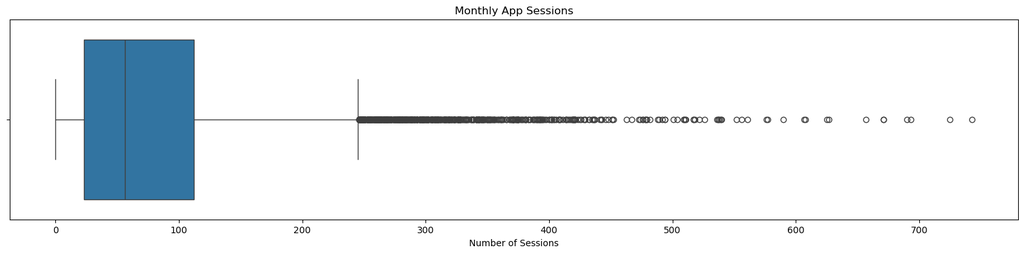

```python
# Box plot
plt.figure(figsize=(20, 4))
sns.boxplot(x=df['sessions'])
plt.title("Monthly App Sessions")
plt.xlabel("Number of Sessions")
plt.show()
```

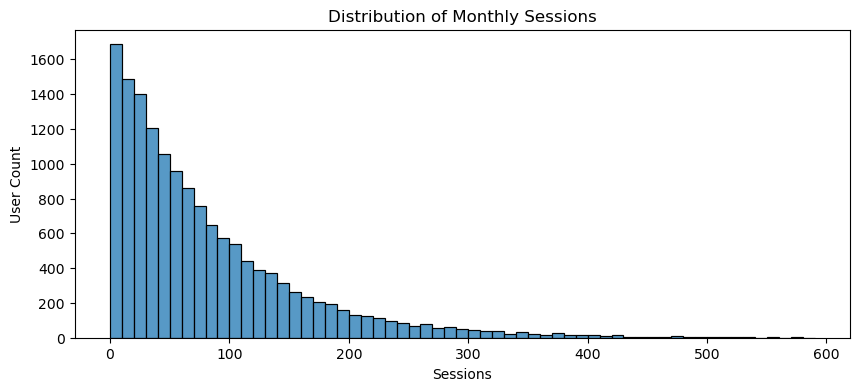

```python
# Histogram
plt.figure(figsize=(10,4))
sns.histplot(x=df['sessions'], bins=range(0,600,10))
plt.title("Distribution of Monthly Sessions")
plt.xlabel("Sessions")
plt.ylabel("User Count")
plt.show()
```

The `sessions` variable shows a **strong right-skewed distribution**, meaning:

- Most users use Waze moderately.
- A small group of users log exceptionally high session counts.
- Around 50% of users have **56 sessions or fewer** in the observed period.
- The extreme values visible in the boxplot likely represent **highly engaged power users**, not data errors.

**Why this matters:**

Understanding this skew is important. These high-engagement users contribute significantly to retention stability, while moderate/low-engagement users may be more vulnerable to churn.

#### **Drives**

*How many trips users completed that were at least 1 km in distance.*

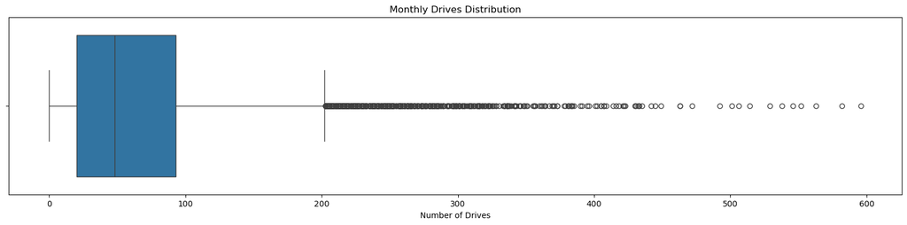

```python
# Box plot
plt.figure(figsize=(20, 4))
sns.boxplot(x=df['drives'])
plt.title("Monthly Drives Distribution")
plt.xlabel("Number of Drives")
plt.show()
```

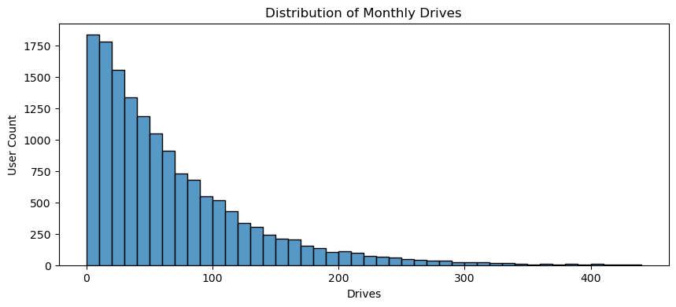

```python
# Histogram
plt.figure(figsize=(10,4))
sns.histplot(x=df['drives'], bins=range(0,450,10))
plt.title("Distribution of Monthly Drives")
plt.xlabel("Drives")
plt.ylabel("User Count")
plt.show()
```

The distribution of `drives` closely mirrors the pattern seen in session frequency:

- The data is **strongly right-skewed**, meaning most users complete a moderate number of trips.
- The **median user completes ~48 trips per month**, indicating regular but not excessive usage.
- A notable long tail exists, where a smaller segment of users completes **over 200–400+ drives**, representing extremely high engagement.
- These high values appear to be **authentic heavy users**, not errors, as they align with realistic frequent-driver behavior.

**Why this matters:**

Users with consistently high driving frequency are typically more dependent on Waze, which often correlates with stronger retention. Meanwhile, moderate and low-frequency users may be more prone to disengagement, making them key focus groups for churn prevention strategies.

#### **Total Sessions**

*Total lifetime estimated number of sessions since a user onboarded.*

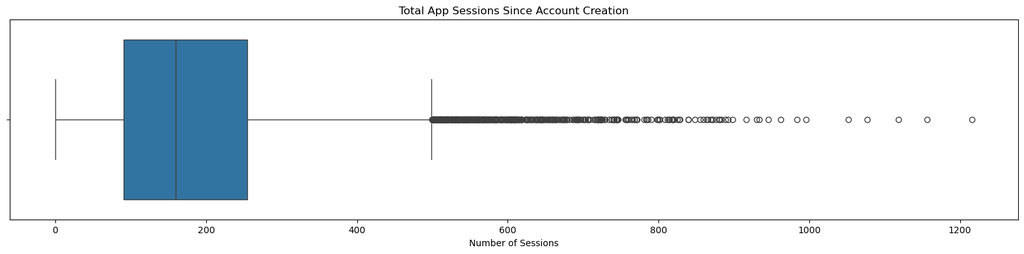

```python
# Box plot
plt.figure(figsize=(20, 4))
sns.boxplot(x=df['total_sessions'])
plt.title("Total App Sessions Since Account Creation")
plt.xlabel("Number of Sessions")
plt.show()
```

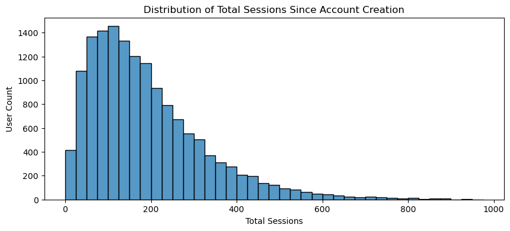

```python
# Histogram
plt.figure(figsize=(10,4))
sns.histplot(x=df['total_sessions'], bins=range(0,1000,25))
plt.title("Distribution of Total Sessions Since Account Creation")
plt.xlabel("Total Sessions")
plt.ylabel("User Count")
plt.show()
```

The `total_sessions` variable also shows a strong right-skewed distribution, meaning:

- Most users accumulate a moderate number of total sessions over their lifetime.
- A smaller subset of users log exceptionally high lifetime session counts.
- The median total sessions is around **160**, indicating half of users have fewer than ~160 total sessions since onboarding.
- Extreme values in the boxplot represent **long-tenured or highly engaged users**, not data errors.

**Why this matters:**

Understanding lifetime usage provides important context for churn behavior. While lifetime sessions reflect **overall historical engagement**, we see that many users’ total usage is still heavily influenced by **recent activity**, reinforcing that current engagement behavior is more predictive of churn risk than legacy usage alone.

#### **Days Since Onboarding**

*How long users have been using Waze since account creation.*

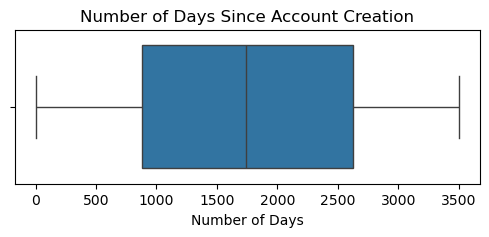

```python
# Box plot
plt.figure(figsize=(6, 2))
sns.boxplot(x=df['n_days_after_onboarding'])
plt.title("Number of Days Since Account Creation")
plt.xlabel("Number of Days")
plt.show()
```

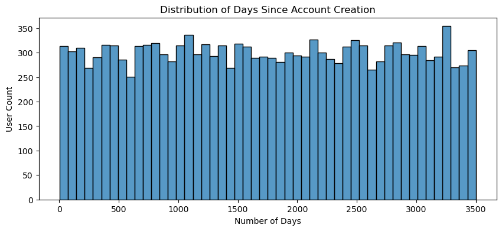

```python
# Histogram
plt.figure(figsize=(10,4))
sns.histplot(x=df['n_days_after_onboarding'], bins=50)
plt.title("Distribution of Days Since Account Creation")
plt.xlabel("Number of Days")
plt.ylabel("User Count")
plt.show()
```

The `n_days_after_onboarding` variable displays a **uniform distribution**, meaning:

- Users joined Waze **steadily over time**, not in a single spike event.
- Tenure ranges from **new users** to those using the app for nearly **3,500 days (~9.5 years)**.
- The middle 50% of users fall roughly between **~1,000 and ~2,600 days**, indicating a healthy mix of both newer and long-tenured users.
- There are no concerning outliers. Variation appears natural rather than data error.

**Why this matters:**

User tenure helps differentiate **new vs. established** users, which is critical for churn interpretation.

- Long-tenured users may churn for different reasons (fatigue, switching apps, life changes).
- Newer users are more likely to churn due to **failed onboarding or weak habit formation**.

This suggests that churn mitigation strategies may need to be **segmented by user tenure** rather than treated as a single uniform population.

#### **Monthly Distance Driven**

*Total kilometers users drove during the month.*

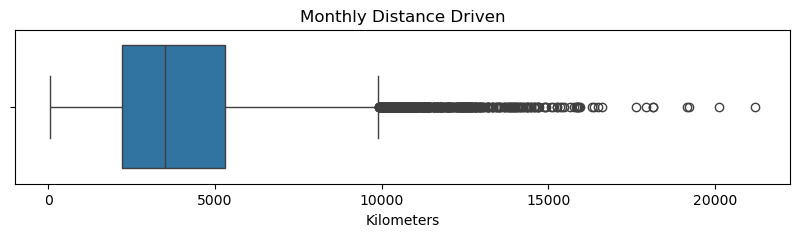

```python
# Box plot
plt.figure(figsize=(10, 2))
sns.boxplot(x=df['driven_km_drives'])
plt.title("Monthly Distance Driven")
plt.xlabel("Kilometers")
plt.show()
```

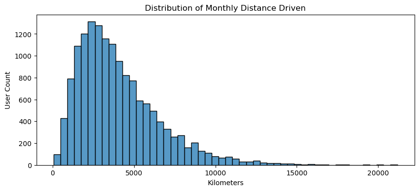

```python
# Histogram
plt.figure(figsize=(10,4))
sns.histplot(x=df['driven_km_drives'], bins=50)
plt.title("Distribution of Monthly Distance Driven")
plt.xlabel("Kilometers")
plt.ylabel("User Count")
plt.show()
```

The `driven_km_drives` variable displays a **strong right-skewed distribution**, meaning:

- Most users drive a **moderate distance** each month.
- A smaller group drives extremely large distances (10,000+ km per month).
- 50% of users drive **around ~3,500 km or fewer** in a month.
- The extreme values in the boxplot are likely **genuine high-travel users** (e.g., commuters, professional drivers), not data errors.

This aligns with what we observed in sessions and drives: there is a core base of “normal” drivers and a distinct segment of **very high-engagement super users**.

**Why this matters:**

Distance driven is a strong indicator of **dependency and engagement** with Waze:

- Users who drive more are likely to rely on navigation more frequently.
- Lower-distance users may represent casual or inconsistent drivers, potentially at higher risk of churn.
- Very high-distance users might show more stable retention but could also churn if competitors provide better routing or features.

This reinforces the importance of segmenting users by **engagement intensity** when analyzing churn.

#### **Monthly Drive Duration**

*Total time users spent driving (in minutes) during the month.*

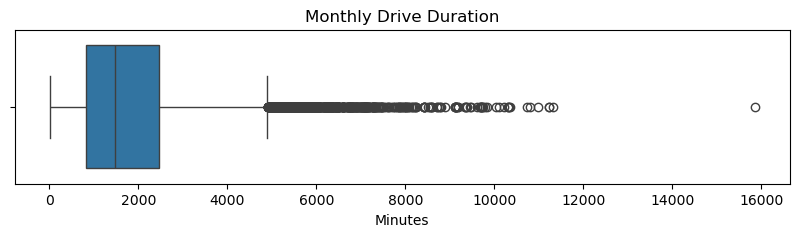

```python
# Box plot
plt.figure(figsize=(10, 2))
sns.boxplot(x=df['duration_minutes_drives'])
plt.title("Monthly Drive Duration")
plt.xlabel("Minutes")
plt.show()
```

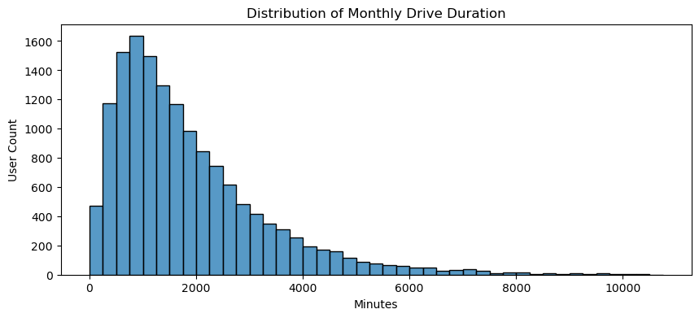

```python
# Histogram
plt.figure(figsize=(10,4))
sns.histplot(x=df['duration_minutes_drives'], bins=range(0,11000,250))
plt.title("Distribution of Monthly Drive Duration")
plt.xlabel("Minutes")
plt.ylabel("User Count")
plt.show()
```

The `duration_minutes_drives` variable shows a **strong right-skewed distribution**, meaning:

- Most users spend a **manageable, moderate amount of time** driving.
- A smaller population drives for **very long total durations** each month.
- 50% of users accumulate **~1,500 minutes or less** of drive time per month, roughly **25 hours of driving**.
- However, some users exceed **10,000 minutes (≈170 hours)**, representing extremely high-engagement drivers such as commuters or professional drivers.

Just like sessions, drives, and kilometers driven, this confirms the presence of **power users** with significantly higher driving activity.

**Why this matters:**

Drive duration reflects **real-world reliance on Waze**:

- Higher total drive time generally indicates stronger app dependency and routine integration.
- Users with short monthly driving duration may reflect light drivers, occasional app users, or potentially disengaging customers.
- Extremely high-duration users are valuable but may also be more sensitive to performance, routing accuracy, and feature quality.

Understanding how **time spent driving** aligns with churn risk helps Waze identify which segments require retention strategies vs. performance optimization.

#### **Activity Days**

*How many days in the month a user opened the Waze app.*

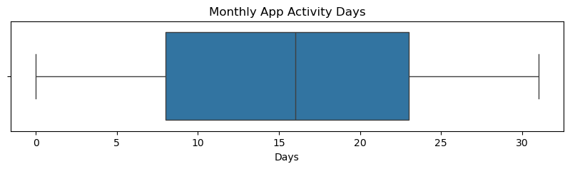

```python
# Box plot
plt.figure(figsize=(10, 2))
sns.boxplot(x=df['activity_days'])
plt.title("Monthly App Activity Days")
plt.xlabel("Days")
plt.show()
```

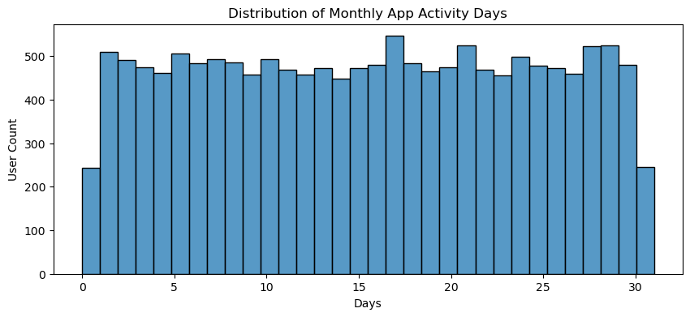

```python
# Histogram
plt.figure(figsize=(10,4))
sns.histplot(x=df['activity_days'], bins=32)
plt.title("Distribution of Monthly App Activity Days")
plt.xlabel("Days")
plt.ylabel("User Count")
plt.show()
```

The `activity_days` variable displays a **surprisingly uniform distribution**, meaning:

- Users are spread fairly evenly across activity frequencies rather than clustering around a single engagement level.
- The median user opened the app **~16 days out of the month** (about every other day).
- There are two interesting edge groups:
  - ~250 users didn’t open the app **at all**
  - ~250 users opened the app **every single day**
- This suggests very diverse usage patterns, from passive or disengaging users to highly habitual users.

Unlike sessions or drive duration, engagement here is **not heavily skewed**. Instead, it indicates a wide spectrum of behavior.

**Why this matters:**

Activity days capture **habit formation and routine**, which are critical for retention:

- Users opening the app consistently (20–30 days/month) likely rely on Waze regularly, signaling stronger retention potential.
- Users with few or zero activity days may be at **higher churn risk**, potentially due to:
  - reduced driving needs,
  - switching to competitors,
  - or losing trust/value in the app.

The diversity in distribution highlights potential **distinct user segments** Waze could target differently - casual drivers, habitual commuters, and fully disengaged users.

#### **Driving Days**

*How many days users physically drove (at least 1 km) during the month.*

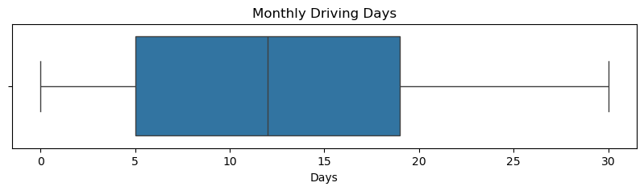

```python
# Box plot
plt.figure(figsize=(10, 2))
sns.boxplot(x=df['driving_days'])
plt.title("Monthly Driving Days")
plt.xlabel("Days")
plt.show()
```

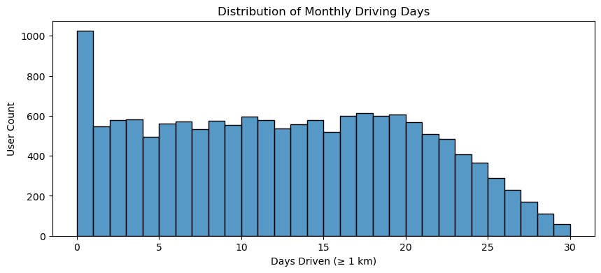

```python
# Histogram
plt.figure(figsize=(10,4))
sns.histplot(x=df['driving_days'], bins=30)
plt.title("Distribution of Monthly Driving Days")
plt.xlabel("Days Driven (≥ 1 km)")
plt.ylabel("User Count")
plt.show()
```

The `driving_days` variable forms an **almost uniform distribution**, meaning users are spread fairly evenly across different numbers of driving days, with:

- A median of **~12–13 driving days per month** (roughly every 2–3 days).
- A gradual tapering off among users who drive nearly every day.
- A **notable spike at 0 days** - around **1,000 users did not drive at all** this month.

**Why this matters:**

This reveals **different engagement modes**:

- Some users treat Waze as a planning, checking, or browsing tool, even when not driving.
- Others drive frequently and rely on Waze regularly, indicating strong functional dependence.
- A meaningful portion of users had no driving activity, which may signal:
  - seasonal driving behavior
  - temporary inactivity
  - or early-stage churn risk

This discrepancy between *opening the app* and *actually driving* is important. It suggests user intent and engagement can’t be understood by a single metric alone. These findings should be revisited when analyzing churn predictors and user segmentation.

#### **Device Type**

*Which platform users primarily access Waze from.*

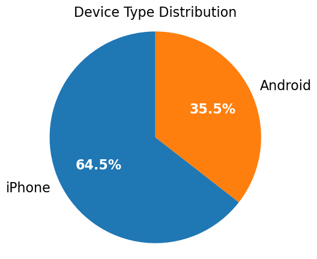

```python
# Pie chart
counts = df['device'].value_counts()

fig, ax = plt.subplots(figsize=(5,5))
wedges, texts, autotexts = ax.pie(
    counts,
    labels=counts.index,
    autopct='%1.1f%%',
    startangle=90
    )

# Outer labels black
for t in texts:
    t.set_color("black")
    t.set_fontsize(16)

# Inner percentage labels white + bold
for a in autotexts:
    a.set_color("white")
    a.set_weight("bold")
    a.set_fontsize(16)

ax.axis('equal')
plt.title("Device Type Distribution", fontsize=16)
plt.show()
```

The dataset is **heavily iPhone-dominant**:

- **~64.5% iPhone users**
- **~35.5% Android users**

This means there are **almost twice as many iPhone users as Android users** represented in this sample.

**Why this matters:**

Understanding device distribution is important for both **product strategy** and **retention modeling**:

- If churn or engagement patterns differ by device, this imbalance could influence model outputs.
- Feature adoption, app performance, or UI behavior may vary between platforms.
- Any retention insights should consider whether differences are due to behavior or simply population size.

This sets the stage for deeper comparison in our churn analysis, especially when examining retention outcomes by device.

#### **Churn Label**

*Whether a user stayed active or stopped using Waze.*

Binary target variable distinguishing:

- **retained** – user continued using the app
- **churned** – user stopped using the app during the observed period

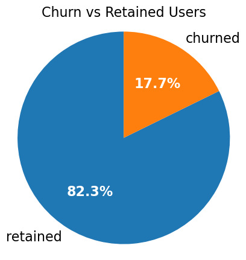

```python
# Pie chart
counts = df['label'].value_counts()

fig, ax = plt.subplots(figsize=(5,5))
wedges, texts, autotexts = ax.pie(
    counts,
    labels=counts.index,
    autopct='%1.1f%%',
    startangle=90
    )

# Outer labels black
for t in texts:
    t.set_color("black")
    t.set_fontsize(16)

# Inner percentage labels white + bold
for a in autotexts:
    a.set_color("white")
    a.set_weight("bold")
    a.set_fontsize(16)

ax.axis('equal')
plt.title("Churn vs Retained Users", fontsize=16)
plt.show()
```

The dataset shows:

- **82.3% of users were retained**
- **17.7% of users churned**

This means **fewer than 1 in 5 users churned** during the observation window. While churn is relatively low, the churned population is still large enough to meaningfully analyze and model.

**Why this matters:**

This distribution is critical because:

- Churn is imbalanced (retained >> churned), which will influence modeling strategies.
- Retention efforts should focus on behaviors that separate the 17.7% who churn.
- Understanding what differentiates churners from retained users will guide actionable product and engagement decisions.

This sets the foundation for deeper behavioral analysis as we later move into comparing engagement metrics by churn status.

#### **Driving Days vs. Activity Days**

*Understanding how often users open the app vs. how often they actually drive.*

Since both `driving_days` and `activity_days` measure behavior across the same monthly time window, comparing them together helps reveal meaningful differences between **engagement** and **actual driving behavior**.

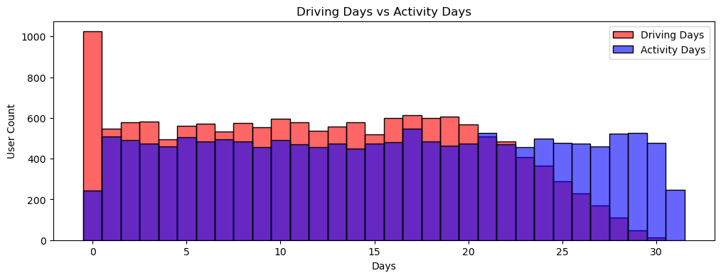

```python
# Histogram
plt.figure(figsize=(12,4))
sns.histplot(df['driving_days'], bins=range(0,33), color='red', alpha=0.6, discrete=True)
sns.histplot(df['activity_days'], bins=range(0,33), color='blue', alpha=0.6, discrete=True)

plt.title("Driving Days vs Activity Days")
plt.xlabel("Days")
plt.ylabel("User Count")
plt.legend(['Driving Days', 'Activity Days'])
plt.show()
```

This visualization highlights an interesting behavioral pattern:

- **Most users opened the app and drove on a similar number of days**
- However, there are:
  - **More users who didn’t drive at all** than users who didn’t open the app at all
  - **More users who opened the app nearly every day** than users who drove nearly every day

In other words:

- Many people **open Waze without driving**
- Very few people **drive every single day**

This makes sense in real-world behavior. Users may open Waze to:

- Check traffic conditions
- Plan routes without starting a trip
- Update preferences
- Or simply out of habit

So although the two features are related, they clearly capture **different user behaviors**.

**Why this matters:**

This distinction is valuable for churn analysis:

- **Activity Days** reflects overall engagement / app habit
- **Driving Days** reflects functional app usage

Users with strong app-opening habits but fewer driving days may still be retained. Users who rarely open the app at all are at higher churn risk.

This suggests that **retention is not driven purely by driving behavior**, but also by how integrated Waze is in users' routine.

#### **Validity Check**

*Maximum days observed:*

```python
print('`driving_days` max = ', df['driving_days'].max())
print('`activity_days` max = ', df['activity_days'].max())
```

```
`driving_days` max =  30
`activity_days` max =  31
```

This confirms that the discrepancy isn’t caused by data quality issues. Users simply engage with the app differently than they drive.

#### **Driving Days vs Activity Days (Scatter Plot)**

To further explore the relationship between **days users opened the app** vs. **days they actually drove**, a scatter plot was created comparing `driving_days` to `activity_days`.

Each dot represents a user.

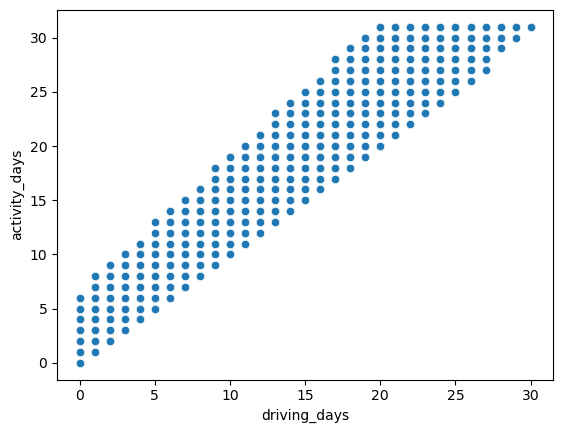

```python
# Scatter plot
sns.scatterplot(data=df, x='driving_days',y='activity_days')
```

This plot reveals a very clean behavioral boundary:

- Users **cannot have more driving days than activity days**
- Every driving day *must* also be an app-usage day
- The data perfectly respects this rule, indicating strong data reliability and logical consistency

This creates a **triangular pattern**:

- Along the diagonal: users who open the app mostly only when they drive
- Above the diagonal: users who open the app more frequently than they drive

Notably, many users cluster **above the diagonal**, meaning:

- Users frequently open Waze even when they aren’t driving
- The app is being used as a planning, checking, or information tool, not just for navigation

**Why this matters:**

This reinforces an earlier finding:

- **Activity Days captures user engagement habit**
- **Driving Days captures mobility and trip behavior**

A user may:

- Be highly engaged (opens app frequently)
- But not necessarily drive frequently

From a churn perspective:

- High `activity_days` suggests habitual app reliance — strong retention indicator
- Low `activity_days` with low `driving_days` may signal disengagement risk

This makes `activity_days` a particularly valuable feature for future churn modeling.

#### **Retention by device**

This visualization compares churn and retention between **Android** and **iPhone** users to determine whether device type plays a meaningful role in churn behavior.

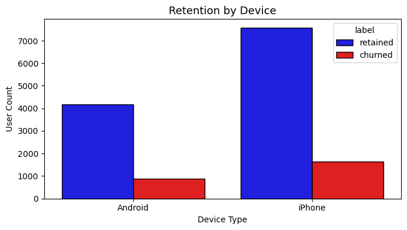

```python
# Histogram
plt.figure(figsize=(7,4))

sns.countplot(
    data=df,
    x='device',
    hue='label',
    order=['Android', 'iPhone'],
    hue_order=['retained', 'churned'],
    palette=['blue', 'red'],
    edgecolor='black'
)

plt.title("Retention by Device", fontsize=13)
plt.xlabel("Device Type")
plt.ylabel("User Count")
plt.tight_layout()
plt.show()
```

A few clear patterns emerge:

- iPhone users make up a larger portion of the dataset overall (consistent with the earlier pie chart showing more iPhone users)
- However, the **ratio of retained vs churned users** remains very similar across both platforms

In other words:

- Both Android and iPhone users churn at nearly the same rate
- Device type does **not** appear to be a meaningful driver of churn in this dataset

This is an important finding, because it rules out a common assumption:

- Performance differences
- Platform experience differences
- OS-specific UX differences

…do **not** appear to be significantly impacting user retention.

**Why this matters:**

From a product and strategy perspective:

- Retention efforts should not be segmented by device platform
- Resources are better spent focusing on **behavioral engagement signals** (e.g., sessions, activity days, navigation behavior)
- Device can safely be treated as a *context variable*, not a primary churn predictor

This supports the earlier insight that **churn is behavior-driven rather than platform-driven**.

#### **Retention by Kilometers Driven per Driving Day**

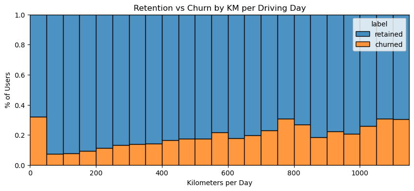

```python
# Creation of `km_per_driving_day` column and inf value clean-up
df['km_per_driving_day'] = df['driven_km_drives']/df['driving_days']
df['km_per_driving_day'] = df['km_per_driving_day'].replace([np.inf],0)

# Stacked Histogram
plt.figure(figsize=(10,4))
sns.histplot(
    data=df[df['km_per_driving_day'] <= 1200],
    x='km_per_driving_day',
    hue='label',
    bins=range(0,1200,50),
    multiple='fill',
    alpha=0.8
    )

plt.title("Retention vs Churn by KM per Driving Day")
plt.xlabel("Kilometers per Day")
plt.ylabel("% of Users")
plt.show()
```

- Most users typically drive **between ~100 km and 600 km per day** on days they use Waze
- Users who drive **shorter distances per day** are more likely to remain retained
- As **average daily distance increases**, the **churn rate becomes noticeably higher**

In simpler terms:

- Light-to-moderate Waze drivers tend to stay
- Heavy-distance drivers are **more likely to churn**

**Why this matters:**

This is a **high-impact behavioral signal**:

- Long-distance drivers may experience fatigue, cost burden, or decreased reliance on navigation on familiar long routes
- These users might stop depending on Waze after initial route learning
- Waze may need **different retention strategies** for long-distance users vs typical commuters

From a product perspective, this suggests opportunities such as:

- Features tailored to professional/long-distance drivers
- Mileage-driven rewards or engagement nudges
- Route optimization highlights to maintain perceived value

#### **Driving Days vs Churn**

How frequently users actually **drive with Waze** in a month, and how this relates to churn likelihood.

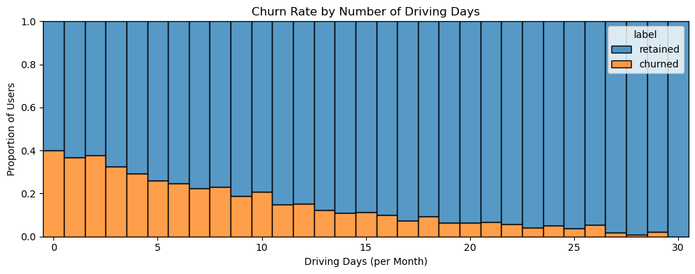

```python
# Stacked Histogram
df_clean = df.dropna(subset=['label'])

plt.figure(figsize=(10,4))

sns.histplot(
    data=df_clean,
    x='driving_days',
    hue='label',
    bins=range(0,32,1),
    multiple='fill',
    discrete=True
)

plt.title("Churn Rate by Number of Driving Days")
plt.xlabel("Driving Days (per Month)")
plt.ylabel("Proportion of Users")
plt.tight_layout()
plt.show()
```

This visualization shows a very clear behavioral signal:

- Users who **barely drove at all** in the last month are significantly more likely to churn
  - Churn rate is highest when driving days are between **0–3 days**
- As driving frequency increases, churn steadily declines
  - Moderate users (10–20 driving days/month) show strong retention
- Heavy drivers have almost **no churn**
  - Users with **30 driving days did not churn at all** in this dataset

This pattern suggests that **recent real-world app dependency** is a strong retention anchor. Users who actively rely on Waze for frequent driving are far less likely to leave.

**Why This Matters:**

This is a powerful product insight:

- **Low driving activity = churn risk**
- **Consistent driving behavior = retention stability**
- Engagement is not just “opening the app,” it’s **functional, purposeful usage**

This can guide strategy in multiple areas:

- Target re-engagement campaigns at low-driving users early
- Encourage light users to build driving habits (nudges, tips, reminders)
- Prioritize features that provide long-term daily driving value

#### **Recent Activity as a Share of Lifetime Engagement**

Understanding how intensely users engaged with Waze in the most recent month relative to their **entire lifetime usage**.

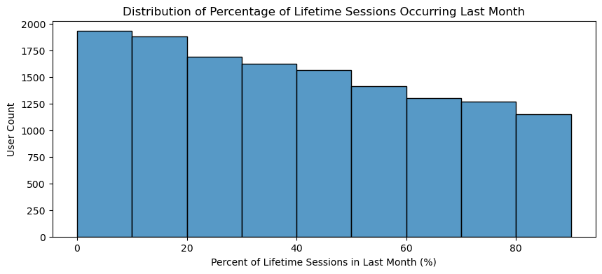

```python
# Column creation
df['percent_sessions_in_last_month'] = df['sessions']/df['total_sessions']*100

# Histogram
plt.figure(figsize=(10,4))
sns.histplot(x=df['percent_sessions_in_last_month'], bins=range(0,100,10))
plt.title("Distribution of Percentage of Lifetime Sessions Occurring Last Month")
plt.xlabel("Percent of Lifetime Sessions in Last Month (%)")
plt.ylabel("User Count")
plt.show()
```

This chart reveals an important, and surprising, pattern:

- A very large portion of users logged **over 40% of their lifetime sessions in just the last month**
- Engagement is heavily concentrated recently rather than evenly spread over time
- This suggests that many users have suddenly become **highly active very recently**

At the same time, when we compare this against user tenure, things become unexpected.

#### **Who Are These “Sudden Power Users”?**

To investigate further, we filtered only users whose **recent month accounted for ≥ 40%** of their lifetime Waze usage, and examined how long they’ve been on the platform.

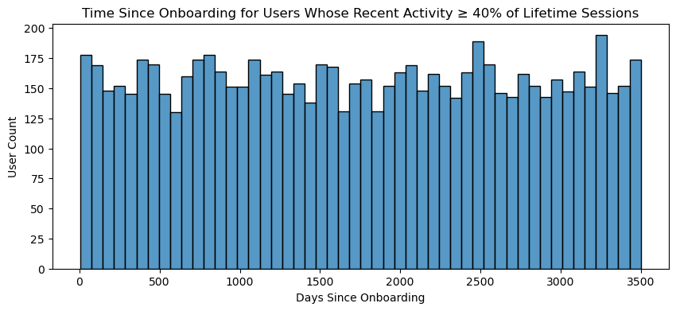

```python
# Histogram
active_users = df[df['percent_sessions_in_last_month'] >= 40]

plt.figure(figsize=(10,4))
sns.histplot(active_users['n_days_after_onboarding'], bins=50)

plt.title("Time Since Onboarding for Users Whose Recent Activity ≥ 40% of Lifetime Sessions")
plt.xlabel("Days Since Onboarding")
plt.ylabel("User Count")
plt.show()
```

Even though these users showed unusually high activity in the most recent month:

- Their **time since account creation is spread almost uniformly**
- Many of them have been on Waze for **multiple years**
- This means the spike is **not just from brand-new users**
- Long-time users suddenly became extremely active

That makes this behavior particularly intriguing.

**Why This Matters:**

This pattern suggests there may have been:

- A **recent external trigger** (e.g., policy change, travel season, fuel crises, commuting changes)
- A **successful product/feature rollout** that increased dependency
- Market or regional factors (e.g., road closures, migration, tourism, weather events)
- Or potentially **data logging changes** that impacted session tracking

Either way, this is a meaningful behavioral anomaly worth business investigation.

**Product Insight Opportunity**

This finding can help Waze:

- Identify **what caused the spike** in recent heavy usage
- Determine whether it correlates with retention improvements
- Understand whether similar events can be intentionally replicated
- Evaluate whether churn risk decreases following such activity bursts

### **Handling Outliers**

Several engagement metrics in this dataset (e.g., sessions, drives, distance, and duration) follow **right-skewed distributions**. The extreme high values are not likely to be data errors. Rather, they appear to represent **very heavy power users**. However, extremely large values can still distort statistical summaries and model behavior.

To reduce their influence while preserving meaningful signal, I applied a **95th-percentile capping strategy** (“winsorization”):

- For each selected numeric feature,
- Compute the value at the 95th percentile
- Replace values above this threshold with the 95th-percentile cutoff
- All other values remain unchanged

This approach preserves distribution shape and rank relationships while preventing a few users from dominating the analysis.

```python
def percentile95(col):
    cap = np.percentile(col, 95)
    return np.where(col > cap, cap, col)

df['sessions'] = percentile95(df['sessions'])
df['drives'] = percentile95(df['drives'])
df['total_sessions'] = percentile95(df['total_sessions'])
df['driven_km_drives'] = percentile95(df['driven_km_drives'])
df['duration_minutes_drives'] = percentile95(df['duration_minutes_drives'])

df.describe()
```

|  | ID | sessions | drives | total_sessions | n_days_after_onboarding | total_navigations_fav1 | total_navigations_fav2 | driven_km_drives | duration_minutes_drives | activity_days | driving_days | km_per_driving_day | percent_sessions_in_last_month |
| --- | --- | --- | --- | --- | --- | --- | --- | --- | --- | --- | --- | --- | --- |
| count | 14999.000000 | 14999.000000 | 14999.000000 | 14999.000000 | 14999.000000 | 14999.000000 | 14999.000000 | 14999.000000 | 14999.000000 | 14999.000000 | 14999.000000 | 14999.000000 | 14999.000000 |
| mean | 7499.000000 | 76.568705 | 64.058204 | 184.031320 | 1749.837789 | 121.605974 | 29.672512 | 3939.632764 | 1789.647426 | 15.537102 | 12.179879 | 578.963113 | 44.925534 |
| std | 4329.982679 | 67.297958 | 55.306924 | 118.600463 | 1008.513876 | 148.121544 | 45.394651 | 2216.041510 | 1222.705167 | 9.004655 | 7.824036 | 1030.094384 | 28.691863 |
| min | 0.000000 | 0.000000 | 0.000000 | 0.220211 | 4.000000 | 0.000000 | 0.000000 | 60.441250 | 18.282082 | 0.000000 | 0.000000 | 0.000000 | 0.000000 |
| 25% | 3749.500000 | 23.000000 | 20.000000 | 90.661156 | 878.000000 | 9.000000 | 0.000000 | 2212.600607 | 835.996260 | 8.000000 | 5.000000 | 136.238895 | 19.622145 |
| 50% | 7499.000000 | 56.000000 | 48.000000 | 159.568115 | 1741.000000 | 71.000000 | 9.000000 | 3493.858085 | 1478.249859 | 16.000000 | 12.000000 | 272.889272 | 42.309703 |
| 75% | 11248.500000 | 112.000000 | 93.000000 | 254.192341 | 2623.500000 | 178.000000 | 43.000000 | 5289.861262 | 2464.362632 | 23.000000 | 19.000000 | 558.686918 | 68.721626 |
| max | 14998.000000 | 243.000000 | 201.000000 | 454.363204 | 3500.000000 | 1236.000000 | 415.000000 | 8889.794236 | 4668.899349 | 31.000000 | 30.000000 | 15420.234110 | 153.063707 |

#### **Features Adjusted**

- `sessions`
- `drives`
- `total_sessions`
- `driven_km_drives`
- `duration_minutes_drives`

After capping, the summary statistics show:

- Reduced max values (brought down to realistic high-engagement behavior)
- Slightly lower standard deviations
- Retained central tendency (median + quartiles unchanged)
- No distortion of user behavior patterns

### **Additional Behavioral Insights**

To better understand the drivers behind churn, the following EDA explores how **recent usage** and **user tenure** relate to retention outcomes.

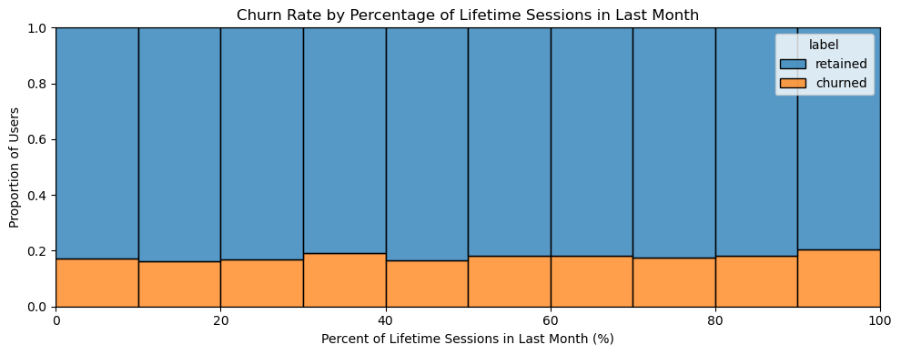

```python
# Churn vs. Recent Activity
df_clean = df.dropna(subset=['label'])

plt.figure(figsize=(10,4))
sns.histplot(
    data=df_clean,
    x='percent_sessions_in_last_month',
    hue='label',
    bins=range(0,101,10),
    multiple='fill'
)

plt.title("Churn Rate by Percentage of Lifetime Sessions in Last Month")
plt.xlabel("Percent of Lifetime Sessions in Last Month (%)")
plt.ylabel("Proportion of Users")
plt.tight_layout()
plt.show()
```

Even though users vary widely in how much they used the app in the most recent month, the churn rate remains fairly stable across most ranges. This suggests that:

- Simply using the app **a lot in the last month** does **not automatically reduce churn**
- Heavy recent usage does not guarantee loyalty
- Other behavioral or contextual factors likely play a stronger role in whether a user leaves or stays

In short, **recency alone is not a strong churn predictor**.

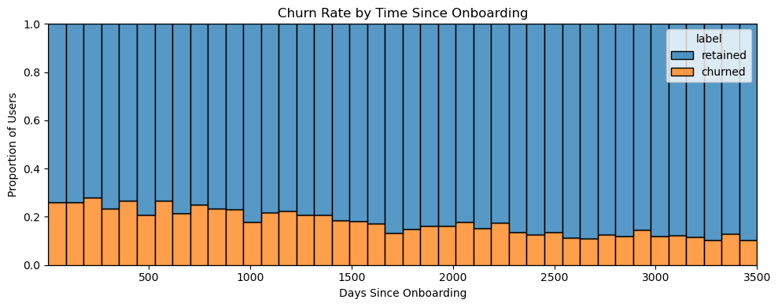

```python
# Tenure vs Churn
plt.figure(figsize=(10,4))
sns.histplot(
    data=df_clean,
    x='n_days_after_onboarding',
    hue='label',
    bins=40,
    multiple='fill'
)

plt.title("Churn Rate by Time Since Onboarding")
plt.xlabel("Days Since Onboarding")
plt.ylabel("Proportion of Users")
plt.tight_layout()
plt.show()
```

Here, a clearer trend emerges:

- Users who have been with the app longer **churn less**
- Newer users are more likely to leave
- Retention stabilizes significantly after extended periods of continued use

This indicates that **tenure is strongly linked to loyalty**. Once users integrate Waze into their routine over time, they are far less likely to churn.

### **Conclusion**

This exploratory analysis builds a strong behavioral understanding of churn within Waze’s user base:

- **Monthly engagement volume** explains some churn behavior
- **Recent spikes in usage** do not meaningfully impact churn on their own
- **Longer user tenure** is one of the strongest stabilizing factors for retention

From here, the next step is to transition from descriptive analysis to predictive modeling. This would involve building a churn prediction model, validating key drivers, and partnering with product stakeholders to turn insights into targeted retention strategies.